# FARMR!SK automatic report

The main pathways of disease entry are: **Animals from other origin** and **Animal transport**.

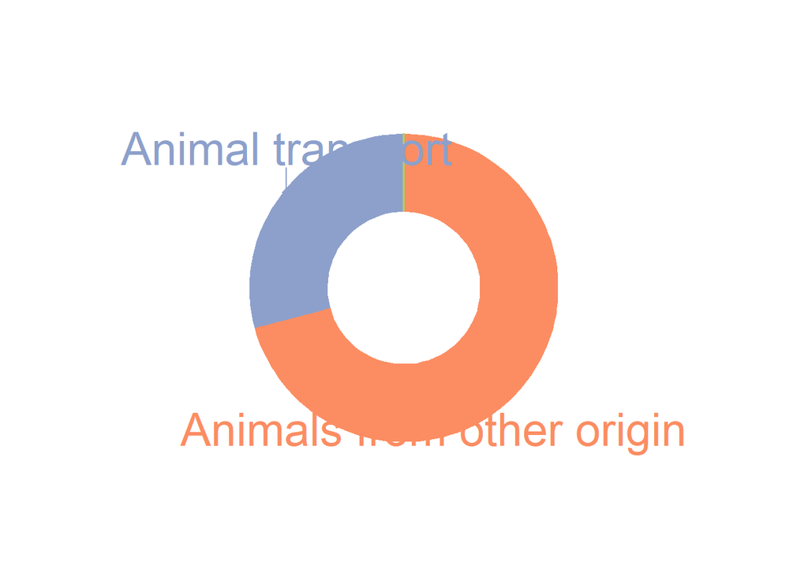

(a) IBR

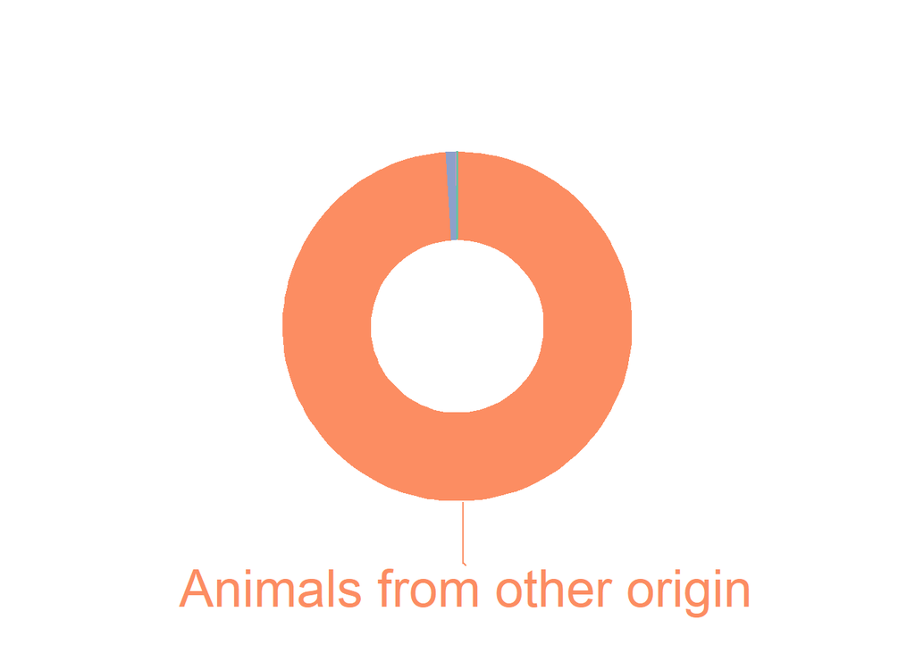

(b) BVD

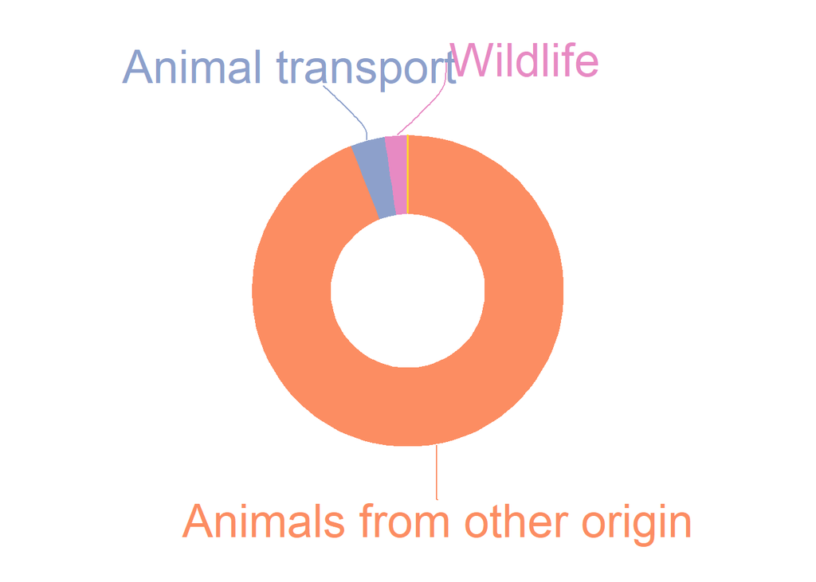

(c) TB

Figure 1.2: Risk of disease entry by pathway

## **Infectious Bovine Rhinotracheitis (IBR)**

### Current risk

Annual risk of IBR entry in the farm: **99.8%** (98.8-100%)

By pathway:

- Animals from other origin: **99.6%** (98-99.9%)
- Animal transport: **40.9%** (26.6-54.9%)
- People visits to the farm: **0.0804%** (0.0401-0.136%)
- Neigbouring farms: **0.00531%** (0.000324-0.0215%)
- Vehicle visits to the farm: **0.000323%** (6.43e-06-0.0016%)

### Risk reduction of biosecurity measures

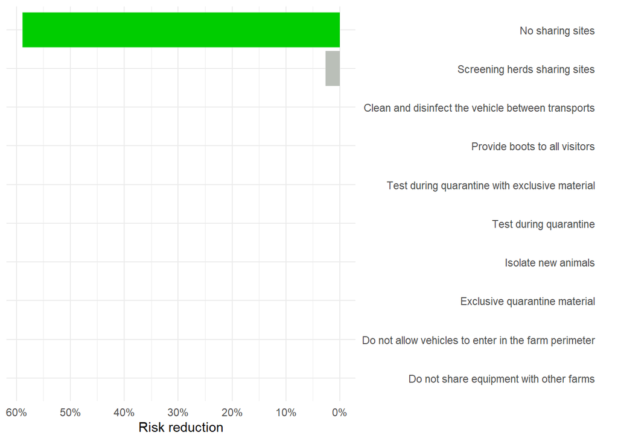

## **Bovine viral diarrhea (BVD)**

### Current risk

Annual risk of BVD entry in the farm: **100%** (100-100%)

By pathway:

- Animals from other origin: **100%** (100-100%)
- Animal transport: **0.925%** (0.204-3.13%)
- People visits to the farm: **0.0801%** (0.0387-0.156%)
- Vehicle visits to the farm: **0.000254%** (4.79e-06-0.00164%)
- Neigbouring farms: **6.11e-11%** (2.55e-13-8.82e-10%)

### Risk reduction of biosecurity measures

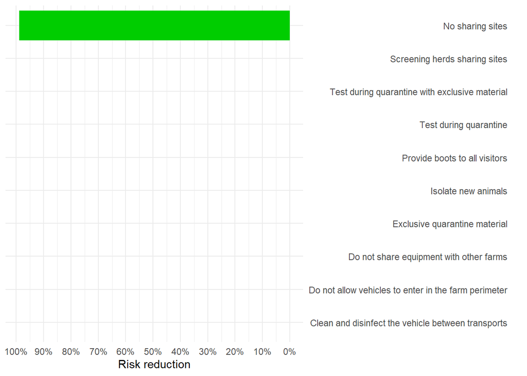

## **Bovine Tuberculosis (TB)**

### Current risk

Annual risk of TB entry in the farm: **0.76%** (0.551-1.05%)

By pathway:

- Animals from other origin: **0.731%** (0.524-1.01%)
- Animal transport: **0.0274%** (0.0116-0.0527%)
- Wildlife: **0.0181%** (0.00442-0.0585%)
- People visits to the farm: **7.04e-05%** (1.64e-05-0.000229%)
- Neigbouring farms: **6.17e-07%** (4.04e-10-1.7e-05%)
- Vehicle visits to the farm: **7.79e-09%** (9.33e-13-6.77e-07%)

### Risk reduction of biosecurity measures

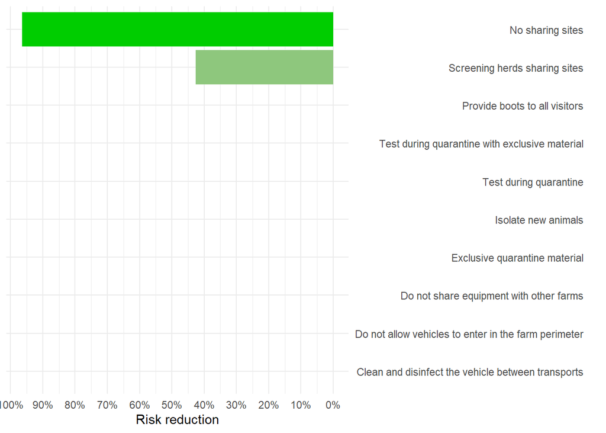

# 🐄 Description of the farm

## Farm information

**Location:** , Andorra

**Farm type:** Beef cattle, NA

**Cattle cens:**

- 20 Calves ( <8 m)
- 6 Heifers (8 - 24 m)
- 2 Adult cows (>24 m)
- 2 Bulls

**Other animals in the farm:**

- **Direct contact with cattle:** 3 dogs, 4 cats
- **No direct contact with cattle:** 5 sheep, 2 horses

**Neighbours**: 1 cattle farms within a 1-2km radious, no direct contact (IBR: 0.00531%, BVD: 6.11e-11%, TB: 6.17e-07%)

## Farm vehicles

| veh_id | Size | Shared | Cleaning |
| --- | --- | --- | --- |
| Remolc (a) | 4m2 | No | From time to time |

## Visits

### People entering the barn

| Visit | Type | Frequency | Boots | Equipment | Risk |
| --- | --- | --- | --- | --- | --- |
| Veterinaris | External veterinarians | 10 | Always used in other farms, never cleaned and disinfected | Always used in other farms, always cleaned and disinfected | IBR: 0.0468%, BVD: 0.0458%, TB: 3.43e-05% |
| Podòleg | Other animal professionals (e.g. hoof trimmer) | 1 | Always used in other farms, sometimes cleaned and disinfected | Always used in other farms, always cleaned and disinfected | IBR: 0.0328%, BVD: 0.0345%, TB: 2.86e-05% |

### Vehicles entering the farm perimeter

| Visit | Type | Frequency | Driver | Risk |
| --- | --- | --- | --- | --- |
| Pinso | Feed vehicle | 12 | - | IBR: 0.000323%, BVD: 0.000254%, TB: 7.79e-09% |

# 🚚 Movements

Animal movements in the last 12 months

| mov_id | When | Origin | Animals moved | Shared site | Vehicle used | Risk |
| --- | --- | --- | --- | --- | --- | --- |
| pastures_estiu | 🔁 Recurrent round: 1 times/year, out for 120 days | Pasture: Andorra | 10 Calves ( <8 m), 6 Heifers (8 - 24 m), 2 Adult cows (>24 m), 2 Bulls | Shared with 300 animals from 10 farms (presence of bulls) | Own Remolc | IBR: 99.6%, BVD: 100%, TB: 0.731% |
| pastures_tardor | 🔁 Recurrent round: 1 times/year, out for 30 days | Pasture: Andorra | 10 Calves ( <8 m), 6 Heifers (8 - 24 m), 2 Adult cows (>24 m), 2 Bulls | No | External | IBR: 40.9%, BVD: 0.925%, TB: 0.0274% |
| 1_macho | ➡️ One-off entry: 2023-05-01 | Other farm/s: Lleida | 1 Bulls | - | Own Remolc | negligible risk |
| 2_novillas | ➡️ One-off entry: 2023-05-01 | Other farm/s: Lleida | 2 Heifers (8 - 24 m) | - | Own Remolc | negligible risk |

### Health status and tests in origin

[output not shown]

### Quarantine

#### Characteristics

*No quarantine*

# 🐗 Wildlife

**Wildlife:** IBR: -, BVD: -, TB: 0.0181%

### Farm water points

*No outdoors water points*

### Pasture water points

*No pasture water points*

# Comments

- Visites de vehicles i pastures a completar (complete)
- 2_novillas: Prenyades? (complete)

# Technical Annex

- Simulation date: 2025-11-18 12:21:18
- Script unification date: 2025-11-17 12:20:43
- Repository: https://github.com/NataliaCiria/biosecurity_model.git
- Last commit: 5b482c75a9928a4d9b1dd0f39f59ed7d93bb09e0
- Last commit date: 2025-11-16 17:22:55
- user_id:
- farm_id: bc2_v2
- Risk timeframe: 360 days
- Calculate all summaries: FALSE
- Automatic what-if scenarios: TRUE
- Analyse model sensitivity: FALSE
- Farm biosecurity survey: bsg_cattle_v4_2_mod_ciria 2014-05-15
- Movements surveys:
  - v4_1_ciria ( 4 ): 1_macho, 2_novillas, pastures_estiu, pastures_tardor